Randomness & Colonel Blotto | 1.0 | 2018-06-29

在本章的内容中，主要探讨竞争。第一部分，主要聚焦在个人因素，包括能力和运气。对于运气，也就是随机过程，进行了定义，并且对其特征进行了详细描述（平均回归）。

在第二部分，主要探讨多人竞争（零和游戏）。使用的模型是上校博弈，对于不均等资源的分配策略，有三点需要注意。其一，一个确定的策略总是可以被打败。其二，对于不均等资源者，最好通过延长战线来获取优势。其三，此博弈类似于一个随机的平衡。多人博弈类似于剪刀石头布。上校博弈可以用来模拟总统竞选、恐怖分子以及任何零和博弈的资源分配策略问题。

# Randomness

Randomness 导致了 Random Walk。后者是前者的结果。

## The sources of Randomness

- $X + \epsilon（Noise）噪音$
- $Error ~误差$
- $Uncertainty ~不确定性$
- $Complexity ~复杂性$

比如决策，一个人的决策取决于其启动和依赖的信息，这些信息是不确定的，并且如何使用这些信息是复杂的机制，此外，即便是做出了决策，这个决策能否执行也有噪音和误差的影响，因此我们可以将基于行为的人类行为看作是一种类似随机过程。

## Skill & Luck

**Define Skill**

$Outcome = a*Luck + (1-a)*Skill$

如果一个队伍，比如阿根廷，表现一直不错，那么可以估计 a 比较小，因为如果 a 比较大，那么运气是随机的，那么表现就更多的随机。

**Skill or Luck?**

因为技能和运气的性质极其不同，前者基本稳定，而后者则不是。通过结果的稳定性可以观察出一个结果更多的依靠技能还是运气。

**The Paradox of Skill**

当非常优秀的选手对决时，如果势均力敌，那么运气更加重要。

[figure not shown]

## Define Random Walk

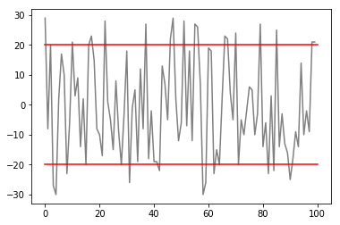

```python
import numpy as np; from matplotlib import pyplot as plt
_ = plt.plot(np.random.randint(-30,30,100),'gray',
         [0,100],[20,20],'r',[0,100],[-20,-20],'r')
```

- After N number of flips, you should expect to be at 0
- For any number K, a random walk will pass both -K and +K an infinite number of times
- For any number K, a random walk will have a streak of K heads and K tails an infinite number of times

赌球连胜可以看作这样一个随机游走过程：每次选择都是不同的个体，而连胜的概率则本质上是从这些所有参与赌球的用户中选择那些连续处在高位的人。

如果一个人持续保持连胜，那么可能是有人遭遇惨败，也有可能是很多人遭遇了失败，但数额都不大。

## Normal Random Walk Model

区别于一般的随机漫步，Normal Random Walk model is as follows: small walks will be frequent, larger walks will not be rare, and huge walks will be rare.

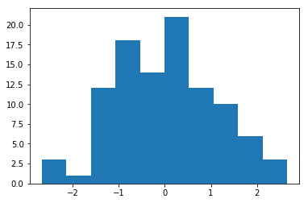

```python
_ = plt.hist(np.random.normal(0,1,100))
```

## 是否存在典型的 Hot hand？

不存在，因为即便是前手表现很好，接下来的胜利概率也是类似的，并不会改变（基于统计）。

**卓越的公司如何诞生？**

大多数所谓卓越的公司，在一段时间后表现都趋近于平均值。而促进他们在历史上成功的原因，可能在新的环境条件下就没有那种运气或者施展条件，尽管这些可能很复杂。但是，依然可以用随机游走模型来进行解释。因此，在活着的公司都会寻求和培育更多的创业项目，以支撑自己的发展。

**未解之谜**

Random Walk 模型有一定的问题，因为像是巴菲特的公司，连续30-40年一直在盈利，所谓的Consistent Winners，难以被这个模型解释。

## 用途：区分 Skill & Luck 以及利用信息不对称

很多时候，在图标上看到的聚类可能不是因为实力，而是因为运气。我们确定它的方法就是放到Random Walk Model中，因为如果是因为运气，那么总会最终趋近于平均值。

使用这个模型可以确定发生的事件是否是随机的，依赖技能更多还是运气更多？

除非利用信息不对称，否则很难赚到钱，因为市场总是会回归到正常水平。比如比特币，在2018年中旬，比特币投资赚到的钱，全部都是被忽悠的那群人新投资带来的血汗钱。

# Colonel Blotto

## Define Colonel Blotto

Colonel Blotto is a model about strategic mismatch and allocation of resources. Blotto leads to a mixed strategy **equilibrium** within which players select **random strategies**.

2 Player each with T troops， N fronts （T >> N）

如果在每条fronts上分配的兵力大于对方，则本条线路获胜。累计总的获胜线路，决定玩家的胜负。这是一个零和游戏。

有趣的是，对于任何已知的策略，如果对手知道你的策略，那么就能打败你，比如 Player 1 在 A B C 三条线路分配 40 40 20 人，那么 Player 2 只需要分配 0 41 21 就可获胜，甚至不用所有的兵力。

对于相同水平玩家而言，这总会变成Skill的悖论。而对于水平相差较大的玩家，则比较的是Skill。

## Applications

竞选，每个州投入产出比不同，需要重点把资源放置在摇摆州。

招聘也是如此。此外还有恐怖分子突袭，只要涉及资源不均等的两方博弈，均可以使用上校战争模型来进行模拟。

## Troop Advantage

**Add dimensions**

对于具有不相等资源的两方，一个重要的因素是，对于弱势者，拉长战线(增加纬度)会更加有利。

++++++++++++++++++++

A = 150， B = 96

Player A 50 50 50 win

Player B 48 48 0 lose

++++++++++++++++++++

A = 150， B = 96

Player B 26 26 26 18 0 win

++++++++++++++++++++

真实情况是，对于恐怖分子，袭击那些意想不到的地方。对于劣质商品，宣传那些鸡毛蒜皮的地方。拉长战线，再优秀的产品也不一定能在这种 Colonel Blotto 游戏中获胜。

**Multiple Player Blotto**

如果 A 战胜了 B，B 战胜了 C，那么不一定 A 能战胜 C。实际上，对于势均力敌的多方，这有可能变成多人的剪刀石头布游戏。

## Luck-Skill or Blotto

前者不涉及零和博弈，主要关注个人的运气和技能分配。而后者则主要关注多人竞争，以及每人在竞争中的博弈/零和收益情况。